# EE5253Report_4466_4578_GP23

Project name: **Customer Churn Prediction**

Team members:

- EG/2021/4466 - De Silva T.S.A.N.H.
- EG/2021/4578 - Jayasinghe D.J.K.V.

Group number: 23

# Introduction

Customer churn prediction is one of the most important areas of research for businesses operating on subscription-based models, such as telecom companies, SaaS providers, and online streaming platforms. Customer churn refers to the phenomenon where customers stop using a company's products or services over a certain period. For businesses, identifying the factors leading to churn and predicting which customers are at high risk of leaving can help in the formulation of targeted retention strategies. This, in turn, enables businesses to reduce churn, enhance customer lifetime value, and improve profitability.

The ability to predict churn with high accuracy relies heavily on the analysis of customer data, such as usage patterns, customer service interactions, and payment history. Traditionally, churn prediction has been done using basic statistical methods; however, with the advent of machine learning, businesses now leverage more sophisticated algorithms to gain deeper insights.

This project seeks to build a machine learning model that predicts customer churn using two widely popular algorithms: **Random Forest** and **XGBoost**. Both models have demonstrated exceptional performance in classification tasks, making them well-suited for churn prediction. The objective of this project is to explore both models, comparing their performance and determining which model provides better predictive accuracy and interpretability for this problem.

By the end of this project, the goal is not only to predict churn but also to gain insights into which features most significantly influence a customer’s decision to churn. This can help businesses create personalized retention strategies and reduce churn by targeting high-risk customers more effectively.

# Literature Survey

Customer churn prediction has been the focus of numerous studies in the business analytics field. Over the years, researchers have explored various machine learning techniques to accurately predict churn, focusing on how to better understand customer behavior and implement preventive measures. Among the many algorithms that have been used, **Random Forest** and **XGBoost** have emerged as two of the most powerful models for classification tasks, including churn prediction.

**Random Forest**

Random Forest is an ensemble learning method that builds multiple decision trees during training and merges their outputs to improve classification accuracy. Each tree in a Random Forest is trained on a equal subset of the data, using a random subset of features. This randomness helps the model generalize well and reduces the risk of overfitting. Random Forest is known for its robustness, ease of use, and ability to handle both categorical and numerical data without the need for extensive preprocessing. It also provides feature importance, which can be useful for understanding which factors contribute most to churn.

**Key Advantages**:

- **Non-linear relationships**: Random Forest can model complex interactions between variables.
- **Interpretability**: It offers insights into feature importance, which can help businesses understand key drivers of churn.
- **Robustness**: The model is resistant to overfitting due to averaging over multiple decision trees.

**Challenges**:

- While Random Forest is easy to use, it can be computationally expensive and time-consuming when dealing with large datasets.
- It may not always perform as well as more advanced boosting algorithms, particularly on unbalanced datasets like churn prediction.

**XGBoost**

XGBoost, which stands for eXtreme Gradient Boosting, is a high-performance implementation of gradient boosting that has become one of the most popular machine learning algorithms for structured data. XGBoost works by building decision trees sequentially, where each new tree attempts to correct the errors made by the previous tree. This boosting process is highly effective for problems like churn prediction, where small improvements in accuracy can lead to substantial performance gains. XGBoost is known for its ability to handle large datasets and its support for various regularization techniques that help control overfitting.

**Key Advantages**:

- **Accuracy**: XGBoost has been shown to outperform other machine learning algorithms in terms of accuracy and computational efficiency.
- **Handling Missing Data**: It is capable of handling missing values in the data, which is often crucial in real-world datasets.
- **Hyperparameter Tuning**: XGBoost provides a large set of hyperparameters that can be fine-tuned to optimize performance, including parameters for regularization and learning rate.

**Challenges**:

- **Complexity**: XGBoost is more complex than Random Forest and requires careful tuning of hyperparameters to avoid overfitting.
- **Interpretability**: While XGBoost provides feature importance scores, the model’s complex boosting process can make it harder to interpret compared to simpler models like Random Forest.

**Comparison Between Random Forest and XGBoost**

A comparison between Random Forest and XGBoost reveals several interesting findings in the context of churn prediction. While Random Forest is a simple and interpretable model, XGBoost often delivers superior accuracy due to its sequential boosting mechanism, which allows the model to learn from the mistakes of prior trees. XGBoost also tends to perform better in situations where the data is noisy or contains irrelevant features. On the other hand, Random Forest is typically faster to train and is easier to understand, which is why it remains a popular choice in situations where model interpretability is paramount.

Previous studies have shown that **XGBoost** often outperforms **Random Forest** in terms of predictive accuracy, particularly when dealing with imbalanced datasets. However, **Random Forest** can still be a strong contender when simplicity and interpretability are more important than raw performance.

In conclusion, both Random Forest and XGBoost have their strengths and weaknesses, and the choice of model depends on the specific requirements of the churn prediction task at hand. This study aims to evaluate both algorithms using a customer churn dataset, comparing their performance to determine the best approach for churn prediction.

# Exploratory Data Analysis and Data Preprocessing

## Importing Libraries

```python
import numpy as np
import pandas as pd
import matplotlib.pyplot as plt
import seaborn as sns
import time
from sklearn.ensemble import RandomForestClassifier
from xgboost import XGBClassifier
from sklearn.model_selection import train_test_split
from sklearn.metrics import (accuracy_score, precision_score, recall_score, f1_score, roc_curve, auc, confusion_matrix, ConfusionMatrixDisplay)
from sklearn.model_selection import GridSearchCV
from sklearn.preprocessing import StandardScaler
```

## Importing Dataset

```python
dataset = pd.read_csv('/content/customer_churn_dataset.csv')

dataset
```

|  | CustomerID | Age | Gender | Tenure | Usage Frequency | Support Calls | Payment Delay | Subscription Type | Contract Length | Total Spend | Last Interaction | Churn |
| --- | --- | --- | --- | --- | --- | --- | --- | --- | --- | --- | --- | --- |
| 0 | 2.0 | 30.0 | Female | 39.0 | 14.0 | 5.0 | 18.0 | Standard | Annual | 932.00 | 17.0 | 1.0 |
| 1 | 3.0 | 65.0 | Female | 49.0 | 1.0 | 10.0 | 8.0 | Basic | Monthly | 557.00 | 6.0 | 1.0 |
| 2 | 4.0 | 55.0 | Female | 14.0 | 4.0 | 6.0 | 18.0 | Basic | Quarterly | 185.00 | 3.0 | 1.0 |
| 3 | 5.0 | 58.0 | Male | 38.0 | 21.0 | 7.0 | 7.0 | Standard | Monthly | 396.00 | 29.0 | 1.0 |
| 4 | 6.0 | 23.0 | Male | 32.0 | 20.0 | 5.0 | 8.0 | Basic | Monthly | 617.00 | 20.0 | 1.0 |
| ... | ... | ... | ... | ... | ... | ... | ... | ... | ... | ... | ... | ... |
| 440828 | 449995.0 | 42.0 | Male | 54.0 | 15.0 | 1.0 | 3.0 | Premium | Annual | 716.38 | 8.0 | 0.0 |
| 440829 | 449996.0 | 25.0 | Female | 8.0 | 13.0 | 1.0 | 20.0 | Premium | Annual | 745.38 | 2.0 | 0.0 |
| 440830 | 449997.0 | 26.0 | Male | 35.0 | 27.0 | 1.0 | 5.0 | Standard | Quarterly | 977.31 | 9.0 | 0.0 |
| 440831 | 449998.0 | 28.0 | Male | 55.0 | 14.0 | 2.0 | 0.0 | Standard | Quarterly | 602.55 | 2.0 | 0.0 |
| 440832 | 449999.0 | 31.0 | Male | 48.0 | 20.0 | 1.0 | 14.0 | Premium | Quarterly | 567.77 | 21.0 | 0.0 |

440833 rows × 12 columns

## Dataset Description

The dataset used in this project contains customer-related features to predict customer churn. Churn, in this context, refers to whether a customer stops using the services of a company. The dataset consists of the following 12 variables.

### **Features**:

1. **CustomerID**:
   - Type: Numerical
   - A unique identifier for each customer.
2. **Age**:
   - Type: Numerical
   - The age of the customer in years.
3. **Gender**:
   - Type: Categorical
   - The gender of the customer (e.g., Male, Female).
4. **Tenure**:
   - Type: Numerical
   - The number of months the customer has been subscribed to the service.
5. **Usage Frequency**:
   - Type: Numerical
   - The frequency with which the customer uses the service.
6. **Support Calls**:
   - Type: Numerical
   - The number of support calls made by the customer.
7. **Payment Delay**:
   - Type: Numerical
   - The number of days the customer’s payment was delayed.
8. **Subscription Type**:
   - Type: Categorical
   - The type of subscription plan the customer has, such as Basic, Standard, or Premium.
9. **Contract Length**:
   - Type: Categorical
   - The duration of the customer's subscription contract, such as Monthly, Quarterly, or Annual.
10. **Total Spend**:
    - Type: Numerical
    - The total amount of money the customer has spent on the service.
11. **Last Interaction**:
    - Type: Numerical
    - The number of days since the customer’s last interaction with the company.
12. **Churn**:
    - Type: Binary (Target Variable)
    - Indicates whether the customer has churned (`1` for churned, `0` for retained).

### **Summary**:

- The dataset contains a mix of numerical and categorical features.
- The target variable is **Churn**, which is binary and suitable for classification tasks.
- This dataset provides rich customer information, enabling insights into the factors influencing churn behavior.

```python
dataset.info()
```

```
<class 'pandas.core.frame.DataFrame'>
RangeIndex: 440833 entries, 0 to 440832
Data columns (total 12 columns):
 #   Column             Non-Null Count   Dtype
---  ------             --------------   -----
 0   CustomerID         440832 non-null  float64
 1   Age                440832 non-null  float64
 2   Gender             440832 non-null  object
 3   Tenure             440832 non-null  float64
 4   Usage Frequency    440832 non-null  float64
 5   Support Calls      440832 non-null  float64
 6   Payment Delay      440832 non-null  float64
 7   Subscription Type  440832 non-null  object
 8   Contract Length    440832 non-null  object
 9   Total Spend        440832 non-null  float64
 10  Last Interaction   440832 non-null  float64
 11  Churn              440832 non-null  float64
dtypes: float64(9), object(3)
memory usage: 40.4+ MB
```

```python
dataset.describe()
```

|  | CustomerID | Age | Tenure | Usage Frequency | Support Calls | Payment Delay | Total Spend | Last Interaction | Churn |
| --- | --- | --- | --- | --- | --- | --- | --- | --- | --- |
| count | 440832.000000 | 440832.000000 | 440832.000000 | 440832.000000 | 440832.000000 | 440832.000000 | 440832.000000 | 440832.000000 | 440832.000000 |
| mean | 225398.667955 | 39.373153 | 31.256336 | 15.807494 | 3.604437 | 12.965722 | 631.616223 | 14.480868 | 0.567107 |
| std | 129531.918550 | 12.442369 | 17.255727 | 8.586242 | 3.070218 | 8.258063 | 240.803001 | 8.596208 | 0.495477 |
| min | 2.000000 | 18.000000 | 1.000000 | 1.000000 | 0.000000 | 0.000000 | 100.000000 | 1.000000 | 0.000000 |
| 25% | 113621.750000 | 29.000000 | 16.000000 | 9.000000 | 1.000000 | 6.000000 | 480.000000 | 7.000000 | 0.000000 |
| 50% | 226125.500000 | 39.000000 | 32.000000 | 16.000000 | 3.000000 | 12.000000 | 661.000000 | 14.000000 | 1.000000 |
| 75% | 337739.250000 | 48.000000 | 46.000000 | 23.000000 | 6.000000 | 19.000000 | 830.000000 | 22.000000 | 1.000000 |
| max | 449999.000000 | 65.000000 | 60.000000 | 30.000000 | 10.000000 | 30.000000 | 1000.000000 | 30.000000 | 1.000000 |

## Handling null/missing values

```python
dataset.isna().sum()
```

|  | 0 |
| --- | --- |
| CustomerID | 1 |
| Age | 1 |
| Gender | 1 |
| Tenure | 1 |
| Usage Frequency | 1 |
| Support Calls | 1 |
| Payment Delay | 1 |
| Subscription Type | 1 |
| Contract Length | 1 |
| Total Spend | 1 |
| Last Interaction | 1 |
| Churn | 1 |

**dtype:** int64

```python
dataset.dropna(inplace=True)
```

```python
dataset.isna().sum()
```

|  | 0 |
| --- | --- |
| CustomerID | 0 |
| Age | 0 |
| Gender | 0 |
| Tenure | 0 |
| Usage Frequency | 0 |
| Support Calls | 0 |
| Payment Delay | 0 |
| Subscription Type | 0 |
| Contract Length | 0 |
| Total Spend | 0 |
| Last Interaction | 0 |
| Churn | 0 |

**dtype:** int64

## Treating Duplicate Records

```python
dataset.duplicated().sum()
```

```
0
```

**Note**

By considering these facts (**only one whole row with missing values and it was dropped** and **no duplicates**) we come to a conclusion that train-test split can be done at the end of data preprocessing as there is no chance of occuring data snooping phenomenon.

## Visualizing Data

### Analyze the distribution of variables

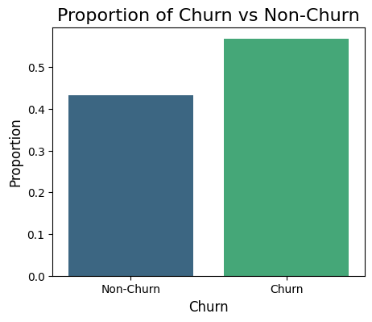

```python
# Checking churn proportions
plt.figure(figsize=(5,4))
churn_counts = dataset['Churn'].value_counts(normalize=True)
sns.barplot(x=churn_counts.index, y=churn_counts.values, palette='viridis')
plt.title('Proportion of Churn vs Non-Churn', fontsize=16)
plt.xlabel('Churn', fontsize=12)
plt.ylabel('Proportion', fontsize=12)
plt.xticks([0, 1], ['Non-Churn', 'Churn'])
plt.show()
```

**Proportion of Churn**:

1. Churn = 1 (Leave): Accounts for a higher rate (about 55%)
2. Churn = 0 (Do not leave): Accounts for about 45%

**Conclusion: The number of customers leaving the service (55%) is higher than the number of customers continuing to use the service (45%)**

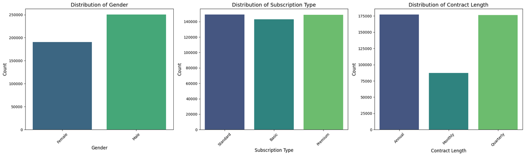

```python
categorical_cols = ['Gender', 'Subscription Type', 'Contract Length']

# Plotting distribution (frequency counts) for categorical variables
fig, axes = plt.subplots(1, 3, figsize=(20, 6))

# Plot bar plots for each categorical variable
for i, col in enumerate(categorical_cols):
    sns.countplot(x=col, data=dataset, palette='viridis', ax=axes[i])
    axes[i].set_title(f'Distribution of {col}', fontsize=14)
    axes[i].set_xlabel(col, fontsize=12)
    axes[i].set_ylabel('Count', fontsize=12)
    axes[i].tick_params(axis='x', rotation=45)

plt.tight_layout()
plt.show()
```

**Categorical feautures**:

1. Gender: The number of male customers (Male) accounts for a larger proportion than female customers (Female)
2. Subscription Type (Type of service package): The number of customers in the three service packages Basic, Standard, and Premium is almost equivalent, the Basic package is slightly lower than the other two types
3. Contract Length: Long-term contracts (Annual, Quarterly) are much more popular than short-term contracts (Monthly)

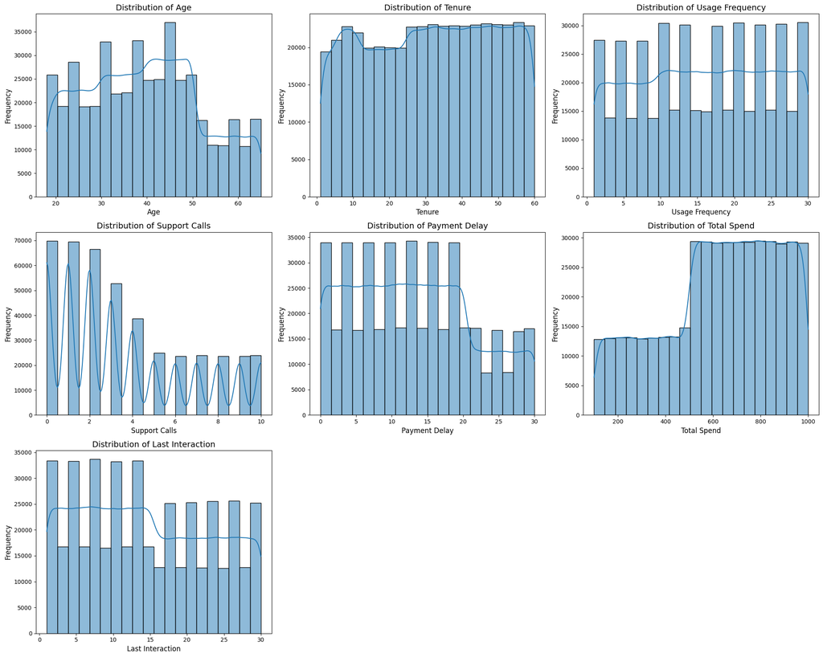

```python
numerical_cols = ['Age', 'Tenure', 'Usage Frequency', 'Support Calls', 'Payment Delay', 'Total Spend', 'Last Interaction']

# Plot histograms for numerical variables
fig, axes = plt.subplots(3, 3, figsize=(20, 16))
axes = axes.flatten()

for i, col in enumerate(numerical_cols):
    sns.histplot(dataset[col], kde=True, bins=20, ax=axes[i])
    axes[i].set_title(f'Distribution of {col}', fontsize=14)
    axes[i].set_xlabel(col, fontsize=12)
    axes[i].set_ylabel('Frequency', fontsize=12)

# Remove empty subplot
fig.delaxes(axes[-1])
fig.delaxes(axes[-2])

plt.tight_layout()
plt.show()
```

### Analyze the relationship between features and churn

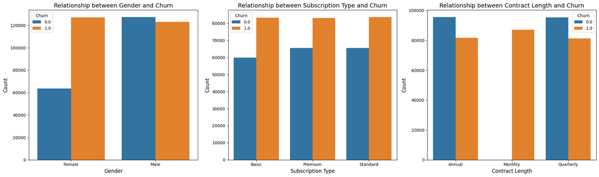

```python
# Create subplots for categorical variables and their relationship with 'Churn'
fig, axes = plt.subplots(nrows=1, ncols=3, figsize=(20, 6))

for i, col in enumerate(categorical_cols):
    churn_counts = dataset.groupby([col, 'Churn']).size().reset_index(name='Count')
    sns.barplot(x=col, y='Count', hue='Churn', data=churn_counts, ax=axes[i])
    axes[i].set_title(f'Relationship between {col} and Churn', fontsize=14)
    axes[i].set_xlabel(col, fontsize=12)
    axes[i].set_ylabel('Count', fontsize=12)
    axes[i].legend(title='Churn')

plt.tight_layout()
plt.show()
```

**Categorical features**:

1. Gender: There is a clear difference between the two genders:
- The number of male customers leaving is less than that of female customers.
- For male customers, the number of customers who continue to use the service (churn=0) is higher than the number of customers who leave.
- In contrast, for female customers, the number of customers leaving is about twice as many as the number staying.
2. Subscription Type (Service package type):
- The "Basic" package has a higher churn rate than "Standard" and "Premium" -> The higher-end package retains customers better.
3. Contract Length:
- "Monthly" contracts have significantly higher churn rates than "Annual" and "Quarterly". Specifically, most customers using the "Monthly" package will not continue to use the service. Meanwhile, long-term contracts help retain customers more effectively.

**Conclusion: There should be service business strategies that focus more on female customers, and at the same time, there should also be strategies to improve the value of the Basic package and the Monthly contract type.**

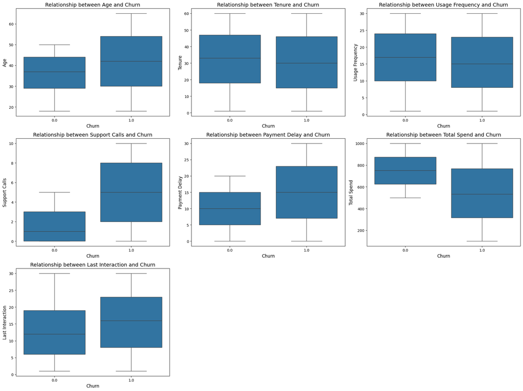

```python
# Create subplots for numerical variables and their relationship with 'Churn'
fig, axes = plt.subplots(nrows=3, ncols=3, figsize=(20, 15))
axes = axes.flatten()

numerical_cols = ['Age', 'Tenure', 'Usage Frequency', 'Support Calls',
                  'Payment Delay', 'Total Spend', 'Last Interaction']

for i, col in enumerate(numerical_cols):
    sns.boxplot(x='Churn', y=col, data=dataset, ax=axes[i])
    axes[i].set_title(f'Relationship between {col} and Churn', fontsize=14)
    axes[i].set_xlabel('Churn', fontsize=12)
    axes[i].set_ylabel(col, fontsize=12)

# Remove empty subplots if any
for j in range(len(numerical_cols), len(axes)):
    fig.delaxes(axes[j])

plt.tight_layout()
plt.show()
```

**Note**

**No outliers were detected** from the boxplots. So, no need of outliers treating step.

**Numerical Variables**:

1. Age:

Median:

- Non-Churn group (Churn=0): Median is around 40 years old.
- Churn group (Churn=1): Median is higher, around 45 years old.

Distribution range (IQR - Interquartile Range):

- Non-Churn group: Distribution focuses mainly on 30 to 50 year olds.
- Churn group: Wider distribution, spanning from 20 to 60 years old.

2. Tenure (Time of use):
- There is high similarity between the two groups churn=0 and churn=1
- The median values are very close (~30 months)
- The distribution range (IQR) is also very similar (~10-50 months)

**Conclusion: Tenure is not a strong factor to distinguish between the two groups Churn and Non-churn**

3. Usage Frequency:
- Similarly, Usage Frequency is not a strong factor to evaluate whether a customer will leave or continue to use the service.
4. Support Calls (Number of support calls):

Non-Churn group (churn=0):

- Median: The number of support calls is not high, about 1-2 times.
- Delivery coverage: Most Non-Churn customers have less than 4 support calls (IQR ranges from 0-4).

**Conclusion: Support Calls are an important factor affecting Churn. The Churn group had a significantly higher number of support calls than the Non-Churn group. The Non-Churn group often does not or rarely calls support, indicating that they are satisfied with the service and do not need to ask for more. Customers who frequently call support (more than 5 times) have a higher tendency to leave the service, possibly due to dissatisfaction with the service.**

5. Payment Delay:

Churn group = 0 (Non-Churn):

- Median (Median): About 10 days.
- Distribution scope: Concentrated in about 5-15 days. There are a few customers whose Payment Delay exceeds 20 days, but this is not significant

Churn group = 1 (Churn):

- Median: Significantly higher, at around 15 days.
- Distribution scope: Wider, with most customers having Payment Delay between 10-20 days and extending to 30 days.

**Conclusion: Payment Delay is an important factor affecting Churn. The chart clearly shows that many customers in the Churn group have higher Payment Delay than the Non-Churn group, meaning that customers with long payment delays (high Payment Delay) are at higher risk of Churn. The wider distribution of the Churn group (with many customers exceeding 20 days) may reflect financial problems or dissatisfaction with the service.**

6. Total Spend:

Churn group = 0 (Non-Churn):

- Median: About 800.
- Distribution range: Concentrated in the 600-900 range, reflecting higher spending compared to the Churn group.
- Distribution is very narrow, with most customers having high and stable spending.

Churn group = 1 (Churn):

- Median: About 500
- Distribution range: Wider than the Non-Churn group, in the range of 300-700

**Conclusion: Total Spend is also an important factor in predicting Churn. The Churn group tends to spend significantly less than the Non-Churn group. Customers who spend little (<600) often have a high risk of churn**

7. Last Interaction (Last interaction time):

Churn group = 0 (Non-Churn):

- Median (Median): About 10 days.
- Distribution scope: Focused on about 5-15 days, with a few customers having a last interaction time of over 20 days.
- Narrow distribution, reflecting that Non-Churn customers often have had recent interactions.

Churn group = 1 (Churn):

- Median: Higher than the Non-Churn group, at about 15 days.
- Distribution range: Wider distribution, within 10-20 days.

**Conclusion: Last Interaction is also a factor that affects whether customers leave or not, but not as strong as the features Support Calls, Payment Delay and Total Spend, but stronger than Tenure and Usage Frequency**

### Analyze the correlation between variables

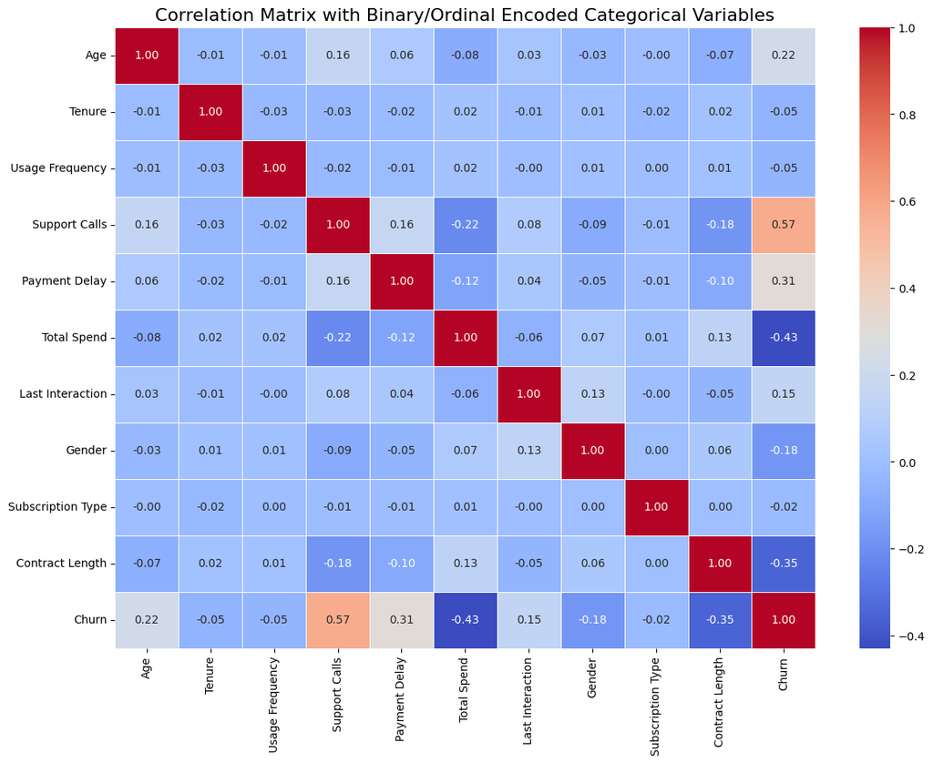

|  | Age | Tenure | Usage Frequency | Support Calls | Payment Delay | Total Spend | Last Interaction | Gender | Subscription Type | Contract Length | Churn |
| --- | --- | --- | --- | --- | --- | --- | --- | --- | --- | --- | --- |
| Age | 1.000000 | -0.011630 | -0.007190 | 0.158451 | 0.061738 | -0.084684 | 0.028980 | -0.031419 | -0.004414 | -0.069303 | 0.218394 |
| Tenure | -0.011630 | 1.000000 | -0.026800 | -0.027640 | -0.016588 | 0.019006 | -0.006903 | 0.007978 | -0.024657 | 0.016925 | -0.051919 |
| Usage Frequency | -0.007190 | -0.026800 | 1.000000 | -0.022013 | -0.014470 | 0.018631 | -0.004662 | 0.007978 | 0.000032 | 0.014058 | -0.046101 |
| Support Calls | 0.158451 | -0.027640 | -0.022013 | 1.000000 | 0.162889 | -0.221594 | 0.077684 | -0.091212 | -0.009820 | -0.178806 | 0.574267 |
| Payment Delay | 0.061738 | -0.016588 | -0.014470 | 0.162889 | 1.000000 | -0.121044 | 0.042708 | -0.048449 | -0.005385 | -0.098028 | 0.312129 |
| Total Spend | -0.084684 | 0.019006 | 0.018631 | -0.221594 | -0.121044 | 1.000000 | -0.056890 | 0.066138 | 0.007131 | 0.133871 | -0.429355 |
| Last Interaction | 0.028980 | -0.006903 | -0.004662 | 0.077684 | 0.042708 | -0.056890 | 1.000000 | 0.134786 | -0.000608 | -0.046014 | 0.149616 |
| Gender | -0.031419 | 0.007978 | 0.007978 | -0.091212 | -0.048449 | 0.066138 | 0.134786 | 1.000000 | 0.002271 | 0.055342 | -0.175395 |
| Subscription Type | -0.004414 | -0.024657 | 0.000032 | -0.009820 | -0.005385 | 0.007131 | -0.000608 | 0.002271 | 1.000000 | 0.004850 | -0.018251 |
| Contract Length | -0.069303 | 0.016925 | 0.014058 | -0.178806 | -0.098028 | 0.133871 | -0.046014 | 0.055342 | 0.004850 | 1.000000 | -0.346666 |
| Churn | 0.218394 | -0.051919 | -0.046101 | 0.574267 | 0.312129 | -0.429355 | 0.149616 | -0.175395 | -0.018251 | -0.346666 | 1.000000 |

```python
# Encode Gender and other categorical variables with ordinal/binary encoding
# Gender: Male = 1, Female = 0
encoded_data_binary = dataset.copy()
encoded_data_binary['Gender'] = encoded_data_binary['Gender'].apply(lambda x: 1 if x == 'Male' else 0)

# Subscription Type: Basic = 0, Standard = 1, Premium = 2
subscription_map = {'Basic': 0, 'Standard': 1, 'Premium': 2}
encoded_data_binary['Subscription Type'] = encoded_data_binary['Subscription Type'].map(subscription_map)

# Contract Length: Monthly = 0, Quarterly = 1, Annual = 2
contract_map = {'Monthly': 0, 'Quarterly': 1, 'Annual': 2}
encoded_data_binary['Contract Length'] = encoded_data_binary['Contract Length'].map(contract_map)

# Combine numerical and newly encoded categorical columns
all_columns_binary = numerical_cols + ['Gender', 'Subscription Type', 'Contract Length', 'Churn']

# Compute the correlation matrix
correlation_matrix_binary = encoded_data_binary[all_columns_binary].corr()

# Plot the heatmap for correlations
plt.figure(figsize=(14, 10))
sns.heatmap(correlation_matrix_binary, annot=True, fmt=".2f", cmap="coolwarm", linewidths=0.5)
plt.title("Correlation Matrix with Binary/Ordinal Encoded Categorical Variables", fontsize=16)
plt.show()

# Return the correlation matrix for review
correlation_matrix_binary
```

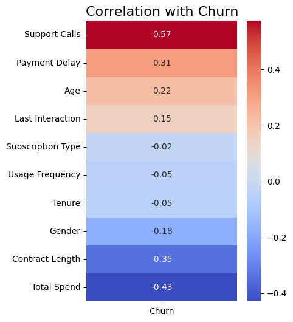

|  | Churn |
| --- | --- |
| Support Calls | 0.574267 |
| Payment Delay | 0.312129 |
| Age | 0.218394 |
| Last Interaction | 0.149616 |
| Subscription Type | -0.018251 |
| Usage Frequency | -0.046101 |
| Tenure | -0.051919 |
| Gender | -0.175395 |
| Contract Length | -0.346666 |
| Total Spend | -0.429355 |

**dtype:** float64

```python
# Calculate correlation of all features with the target (Churn)
target_corr = correlation_matrix_binary['Churn'].drop('Churn').sort_values(ascending=False)

# Plot the correlation of each variable with Churn
plt.figure(figsize=(4, 6))
sns.heatmap(target_corr.to_frame(), annot=True, cmap='coolwarm', fmt=".2f", cbar=True)
plt.title("Correlation with Churn", fontsize=16)
plt.show()

# Display the correlations for reference
target_corr
```

**Note**

Although some features show less correlation with target variable, we prevent from feature selection as our dataset consists with only 11 feature variables, so it may cause data loss which will lead to inaccurate predictions.

## Handling Categorical Variables

**Note**

For columns with categorical data types such as Gender, Subscription Type, Contract Length must preprocess into numerical values to be able to include them in the model. We decided to encode with **Label Encoding** due to following reasons.

- By analysing the **Gender** feature we came to a conclusion that female customers are more likely to leave, so we use 'Male': 1 and 'Female': 0.
- In **Subscription Type** feature 'Basic' package has a higher churn rate than 'Standard' and 'Premium', so higher-end package retains customers better. This concludes to use 'Basic': 0, 'Standard': 1 and 'Premium': 2.
- By considering **Contranct Length** feature we had a conclusion that specifically, most customers using the "Monthly" package will not continue to use the service. Meanwhile, long-term contracts help retain customers more effectively. So we use 'Monthly': 0, 'Quarterly': 1 and 'Annual': 2.

### Normalize categorical data into numerical format using Label Encoding

```python
# Encode categorical variables to numeric values
encoded_dataset = dataset.copy()
encoded_dataset['Gender'] = encoded_dataset['Gender'].apply(lambda x: 1 if x == 'Male' else 0)

subscription_map = {'Basic': 0, 'Standard': 1, 'Premium': 2}
encoded_dataset['Subscription Type'] = encoded_dataset['Subscription Type'].map(subscription_map)

contract_map = {'Monthly': 0, 'Quarterly': 1, 'Annual': 2}
encoded_dataset['Contract Length'] = encoded_dataset['Contract Length'].map(contract_map)
```

```python
encoded_dataset
```

|  | CustomerID | Age | Gender | Tenure | Usage Frequency | Support Calls | Payment Delay | Subscription Type | Contract Length | Total Spend | Last Interaction | Churn |
| --- | --- | --- | --- | --- | --- | --- | --- | --- | --- | --- | --- | --- |
| 0 | 2.0 | 30.0 | 0 | 39.0 | 14.0 | 5.0 | 18.0 | 1 | 2 | 932.00 | 17.0 | 1.0 |
| 1 | 3.0 | 65.0 | 0 | 49.0 | 1.0 | 10.0 | 8.0 | 0 | 0 | 557.00 | 6.0 | 1.0 |
| 2 | 4.0 | 55.0 | 0 | 14.0 | 4.0 | 6.0 | 18.0 | 0 | 1 | 185.00 | 3.0 | 1.0 |
| 3 | 5.0 | 58.0 | 1 | 38.0 | 21.0 | 7.0 | 7.0 | 1 | 0 | 396.00 | 29.0 | 1.0 |
| 4 | 6.0 | 23.0 | 1 | 32.0 | 20.0 | 5.0 | 8.0 | 0 | 0 | 617.00 | 20.0 | 1.0 |
| ... | ... | ... | ... | ... | ... | ... | ... | ... | ... | ... | ... | ... |
| 440828 | 449995.0 | 42.0 | 1 | 54.0 | 15.0 | 1.0 | 3.0 | 2 | 2 | 716.38 | 8.0 | 0.0 |
| 440829 | 449996.0 | 25.0 | 0 | 8.0 | 13.0 | 1.0 | 20.0 | 2 | 2 | 745.38 | 2.0 | 0.0 |
| 440830 | 449997.0 | 26.0 | 1 | 35.0 | 27.0 | 1.0 | 5.0 | 1 | 1 | 977.31 | 9.0 | 0.0 |
| 440831 | 449998.0 | 28.0 | 1 | 55.0 | 14.0 | 2.0 | 0.0 | 1 | 1 | 602.55 | 2.0 | 0.0 |
| 440832 | 449999.0 | 31.0 | 1 | 48.0 | 20.0 | 1.0 | 14.0 | 2 | 1 | 567.77 | 21.0 | 0.0 |

440832 rows × 12 columns

## Prepare features (X) - labels (y)

```python
X = encoded_dataset.drop('Churn', axis=1)
y = encoded_dataset['Churn']
```

## Train-test split: training set (90%) and test set (10%)

```python
X_train, X_test, y_train, y_test = train_test_split(X, y, test_size=0.1, random_state=42, stratify=y)
```

```python
X_train.shape, X_test.shape, y_train.shape, y_test.shape
```

```
((396748, 11), (44084, 11), (396748,), (44084,))
```

## Feature Scaling

```python
# Standardize numerical features
scaler = StandardScaler()
X_train_scaled = scaler.fit_transform(X_train)
X_test_scaled = scaler.transform(X_test)
```

**Note**

Data is not imbalanced (~ 45% churn=0 and ~ 55% churn=1) -> It is not necessary to balance data using techniques like SMOTE, Undersampling. So we can directly move with model implementation.

# Model Implementation

## Random Forest

```python
# Random Forest Model Training and Evaluation
print("Processing: Random Forest...")

# Define Random Forest and parameter grid
rf_model = RandomForestClassifier(random_state=42)
rf_param_grid = {
    'n_estimators': [50, 100],
    'max_depth': [5, 10],
    'min_samples_split': [5, 10],
    'min_samples_leaf': [1, 2]
}

# Hyperparameter tuning with GridSearchCV
rf_grid = GridSearchCV(
    estimator=rf_model,
    param_grid=rf_param_grid,
    cv=2,
    scoring='accuracy',
    verbose=2,
    n_jobs=-1
)

# Measure training time
start_time = time.time()
rf_grid.fit(X_train_scaled, y_train)
train_time = time.time() - start_time

# Best model from grid search
rf_best_model = rf_grid.best_estimator_
print(f"Best parameters for Random Forest:", rf_grid.best_params_)
print(f"Best cross-validation score for Random Forest: {rf_grid.best_score_}")
```

```
Processing: Random Forest...
Fitting 2 folds for each of 16 candidates, totalling 32 fits
```

```
Best parameters for Random Forest: {'max_depth': 10, 'min_samples_leaf': 1, 'min_samples_split': 5, 'n_estimators': 50}
Best cross-validation score for Random Forest: 0.9962217830965752
```

**Note - Hyperparameter Tuning**

We initially experimented with a broader range of hyperparameter values and a higher cross-validation (CV) setting to thoroughly explore the parameter space. However, this approach significantly increased the training time. To ensure a more efficient yet effective training process, we decided to focus on two carefully chosen hyperparameter values for each hyperparameter and set CV to 2.

```python
# Evaluate metrics for training dataset
rf_y_train_pred = rf_best_model.predict(X_train_scaled)
rf_train_metrics = {
    "Model": "Random Forest (Train)",
    "Accuracy": accuracy_score(y_train, rf_y_train_pred),
    "Precision": precision_score(y_train, rf_y_train_pred),
    "Recall": recall_score(y_train, rf_y_train_pred),
    "F1 Score": f1_score(y_train, rf_y_train_pred),
    "Training Time (s)": train_time
}

# Print training metrics
print("Training Dataset Metrics:")
for key, value in rf_train_metrics.items():
    print(f"\t{key}: {value}")
```

```
Training Dataset Metrics:
	Model: Random Forest (Train)
	Accuracy: 0.9959798159032938
	Precision: 0.9931394363212545
	Recall: 0.9998177769678976
	F1 Score: 0.9964674171836345
	Training Time (s): 326.1268081665039
```

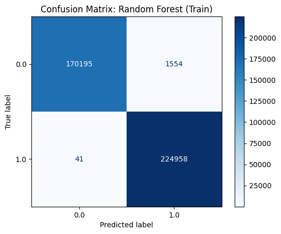

```python
# Confusion matrix for training dataset
cm_train = confusion_matrix(y_train, rf_y_train_pred)
disp_train = ConfusionMatrixDisplay(confusion_matrix=cm_train, display_labels=rf_best_model.classes_)
disp_train.plot(cmap=plt.cm.Blues)
plt.title("Confusion Matrix: Random Forest (Train)")
plt.show()
```

```python
# Measure prediction time
start_time = time.time()
rf_y_pred = rf_best_model.predict(X_test_scaled)
predict_time = time.time() - start_time
```

```python
# Evaluate metrics for test dataset
rf_test_metrics = {
    "Model": "Random Forest (Test)",
    "Accuracy": accuracy_score(y_test, rf_y_pred),
    "Precision": precision_score(y_test, rf_y_pred),
    "Recall": recall_score(y_test, rf_y_pred),
    "F1 Score": f1_score(y_test, rf_y_pred),
    "Prediction Time (s)": predict_time
}

# Print test metrics
print("Test Dataset Metrics:")
for key, value in rf_test_metrics.items():
    print(f"\t{key}: {value}")
```

```
Test Dataset Metrics:
	Model: Random Forest (Test)
	Accuracy: 0.9952590509028219
	Precision: 0.9919434853355559
	Recall: 0.99976
	F1 Score: 0.99583640456601
	Prediction Time (s): 0.13321328163146973
```

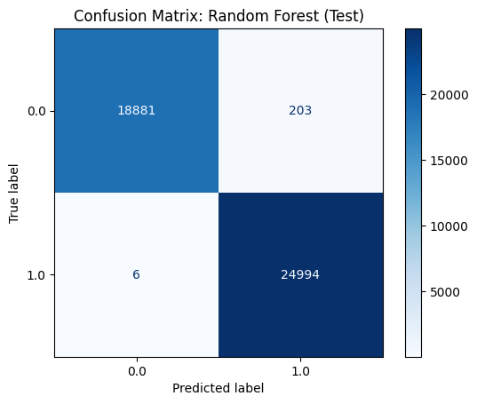

```python
# Confusion matrix for test dataset
cm_test = confusion_matrix(y_test, rf_y_pred)
disp_test = ConfusionMatrixDisplay(confusion_matrix=cm_test, display_labels=rf_best_model.classes_)
disp_test.plot(cmap=plt.cm.Blues)
plt.title("Confusion Matrix: Random Forest (Test)")
plt.show()
```

```python
# Collect ROC curve data for Random Forest
if hasattr(rf_best_model, "predict_proba"):
    # For Test Dataset
    rf_y_prob_test = rf_best_model.predict_proba(X_test_scaled)[:, 1]
    fpr_rf_test, tpr_rf_test, _ = roc_curve(y_test, rf_y_prob_test)
    roc_auc_rf_test = auc(fpr_rf_test, tpr_rf_test)
    roc_data_rf_test = {"Random Forest (Test)": (fpr_rf_test, tpr_rf_test, roc_auc_rf_test)}

    # For Training Dataset
    rf_y_prob_train = rf_best_model.predict_proba(X_train_scaled)[:, 1]
    fpr_rf_train, tpr_rf_train, _ = roc_curve(y_train, rf_y_prob_train)
    roc_auc_rf_train = auc(fpr_rf_train, tpr_rf_train)
    roc_data_rf_train = {"Random Forest (Train)": (fpr_rf_train, tpr_rf_train, roc_auc_rf_train)}
```

```python
# Convert results to DataFrame
timed_results_rf_df = pd.DataFrame([rf_train_metrics, rf_test_metrics])
```

## XGBoost

```python
# XGBoost Model Training and Evaluation
print("Processing: XGBoost...")

# Define XGBoost and parameter grid
xgb_model = XGBClassifier(random_state=42, eval_metric='logloss')
xgb_param_grid = {
    'n_estimators': [50, 100],
    'max_depth': [2, 4],
    'learning_rate': [0.1, 0.2],
    'subsample': [0.8, 1],
    'colsample_bytree': [0.8, 1]
}

# Hyperparameter tuning with GridSearchCV
xgb_grid = GridSearchCV(
    estimator=xgb_model,
    param_grid=xgb_param_grid,
    cv=2,
    scoring='accuracy',
    verbose=2,
    n_jobs=-1
)

# Measure training time
start_time = time.time()
xgb_grid.fit(X_train_scaled, y_train)
train_time = time.time() - start_time

# Best model from grid search
xgb_best_model = xgb_grid.best_estimator_
print(f"Best parameters for XGBoost:", xgb_grid.best_params_)
print(f"Best cross-validation score for XGBoost: {xgb_grid.best_score_}")
```

```
Processing: XGBoost...
Fitting 2 folds for each of 32 candidates, totalling 64 fits
Best parameters for XGBoost: {'colsample_bytree': 1, 'learning_rate': 0.2, 'max_depth': 4, 'n_estimators': 100, 'subsample': 0.8}
Best cross-validation score for XGBoost: 0.9999571516428565
```

**Note - Hyperparameter Tuning**

We initially experimented with a broader range of hyperparameter values and a higher cross-validation (CV) setting to thoroughly explore the parameter space. However, this approach significantly increased the training time. To ensure a more efficient yet effective training process, we decided to focus on two carefully chosen hyperparameter values for each hyperparameter and set CV to 2.

```python
# Evaluate metrics for training dataset
xgb_y_train_pred = xgb_best_model.predict(X_train_scaled)
xgb_train_metrics = {
    "Model": "XGBoost (Train)",
    "Accuracy": accuracy_score(y_train, xgb_y_train_pred),
    "Precision": precision_score(y_train, xgb_y_train_pred),
    "Recall": recall_score(y_train, xgb_y_train_pred),
    "F1 Score": f1_score(y_train, xgb_y_train_pred),
    "Training Time (s)": train_time
}

# Print training metrics
print("Training Dataset Metrics:")
for key, value in xgb_train_metrics.items():
    print(f"\t{key}: {value}")
```

```
Training Dataset Metrics:
	Model: XGBoost (Train)
	Accuracy: 0.9999773155756299
	Precision: 0.9999866664296254
	Recall: 0.9999733332148143
	F1 Score: 0.9999799997777753
	Training Time (s): 89.75960516929626
```

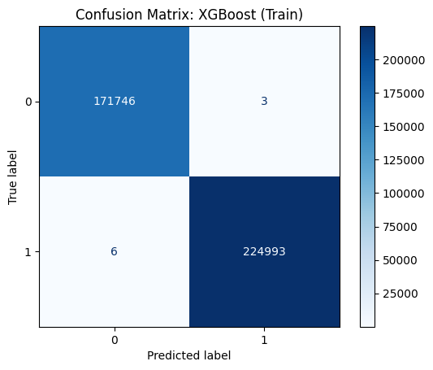

```python
# Confusion matrix for training dataset
cm_train = confusion_matrix(y_train, xgb_y_train_pred)
disp_train = ConfusionMatrixDisplay(confusion_matrix=cm_train, display_labels=xgb_best_model.classes_)
disp_train.plot(cmap=plt.cm.Blues)
plt.title("Confusion Matrix: XGBoost (Train)")
plt.show()
```

```python
# Measure prediction time
start_time = time.time()
xgb_y_pred = xgb_best_model.predict(X_test_scaled)
predict_time = time.time() - start_time
```

```python
# Evaluate metrics for test dataset
xgb_test_metrics = {
    "Model": "XGBoost (Test)",
    "Accuracy": accuracy_score(y_test, xgb_y_pred),
    "Precision": precision_score(y_test, xgb_y_pred),
    "Recall": recall_score(y_test, xgb_y_pred),
    "F1 Score": f1_score(y_test, xgb_y_pred),
    "Prediction Time (s)": predict_time
}

# Print test metrics
print("Test Dataset Metrics:")
for key, value in xgb_test_metrics.items():
    print(f"\t{key}: {value}")
```

```
Test Dataset Metrics:
	Model: XGBoost (Test)
	Accuracy: 0.9999319480990836
	Precision: 0.999959998399936
	Recall: 0.99992
	F1 Score: 0.999939998799976
	Prediction Time (s): 0.08844947814941406
```

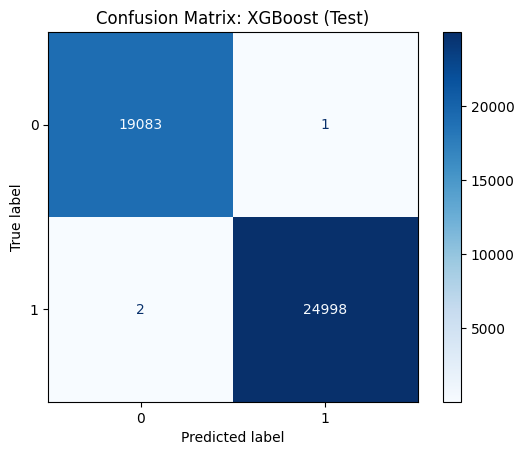

```python
# Confusion matrix for test dataset
cm_test = confusion_matrix(y_test, xgb_y_pred)
disp_test = ConfusionMatrixDisplay(confusion_matrix=cm_test, display_labels=xgb_best_model.classes_)
disp_test.plot(cmap=plt.cm.Blues)
plt.title("Confusion Matrix: XGBoost (Test)")
plt.show()
```

```python
# Collect ROC curve data for XGBoost
if hasattr(xgb_best_model, "predict_proba"):
    # For Test Dataset
    xgb_y_prob_test = xgb_best_model.predict_proba(X_test_scaled)[:, 1]
    fpr_xgb_test, tpr_xgb_test, _ = roc_curve(y_test, xgb_y_prob_test)
    roc_auc_xgb_test = auc(fpr_xgb_test, tpr_xgb_test)
    roc_data_xgb_test = {"XGBoost (Test)": (fpr_xgb_test, tpr_xgb_test, roc_auc_xgb_test)}

    # For Training Dataset
    xgb_y_prob_train = xgb_best_model.predict_proba(X_train_scaled)[:, 1]
    fpr_xgb_train, tpr_xgb_train, _ = roc_curve(y_train, xgb_y_prob_train)
    roc_auc_xgb_train = auc(fpr_xgb_train, tpr_xgb_train)
    roc_data_xgb_train = {"XGBoost (Train)": (fpr_xgb_train, tpr_xgb_train, roc_auc_xgb_train)}
```

```python
# Convert results to DataFrame
timed_results_xgb_df = pd.DataFrame([xgb_train_metrics, xgb_test_metrics])
```

# Model Evaluation and Discussion

```python
# Combine the timed results into a single DataFrame
timed_results_combined_df = pd.concat(
    [
        pd.DataFrame([rf_train_metrics, rf_test_metrics]),
        pd.DataFrame([xgb_train_metrics, xgb_test_metrics])
    ],
    ignore_index=True
)

# Display the combined DataFrame
timed_results_combined_df
```

|  | Model | Accuracy | Precision | Recall | F1 Score | Training Time (s) | Prediction Time (s) |
| --- | --- | --- | --- | --- | --- | --- | --- |
| 0 | Random Forest (Train) | 0.995980 | 0.993139 | 0.999818 | 0.996467 | 326.126808 | NaN |
| 1 | Random Forest (Test) | 0.995259 | 0.991943 | 0.999760 | 0.995836 | NaN | 0.133213 |
| 2 | XGBoost (Train) | 0.999977 | 0.999987 | 0.999973 | 0.999980 | 89.759605 | NaN |
| 3 | XGBoost (Test) | 0.999932 | 0.999960 | 0.999920 | 0.999940 | NaN | 0.088449 |

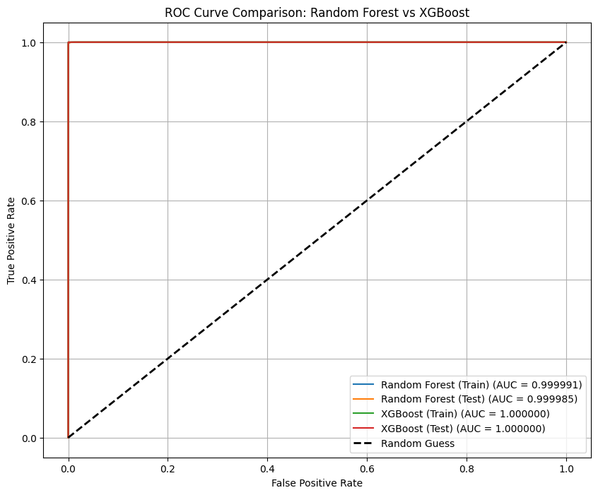

```python
# Plot ROC curves for Random Forest and XGBoost
plt.figure(figsize=(10, 8))

# Random Forest ROC curve
if 'roc_data_rf_train' in locals():
    for model_name, roc_values in {**roc_data_rf_train, **roc_data_rf_test}.items():
        fpr, tpr, roc_auc = roc_values
        plt.plot(fpr, tpr, label=f"{model_name} (AUC = {roc_auc:.6f})")

# XGBoost ROC curve
if 'roc_data_xgb_train' in locals():
    for model_name, roc_values in {**roc_data_xgb_train, **roc_data_xgb_test}.items():
        fpr, tpr, roc_auc = roc_values
        plt.plot(fpr, tpr, label=f"{model_name} (AUC = {roc_auc:.6f})")

# Random guess line
plt.plot([0, 1], [0, 1], 'k--', lw=2, label='Random Guess')

# Plot customization
plt.title("ROC Curve Comparison: Random Forest vs XGBoost")
plt.xlabel("False Positive Rate")
plt.ylabel("True Positive Rate")
plt.legend(loc="lower right")
plt.grid()
plt.show()
```

In this project, two machine learning models, Random Forest and XGBoost, were implemented to predict customer churn. Both models were evaluated using various performance metrics, including accuracy, precision, recall, F1-score, training time, prediction time, and the Receiver Operating Characteristic - Area Under Curve (ROC-AUC) score. The results are summarized below:

| Model | Accuracy | Precision | Recall | F1 Score | ROC-AUC | Training Time (s) | Prediction Time (s) |
| --- | --- | --- | --- | --- | --- | --- | --- |
| Random Forest (Train) | 0.995980 | 0.993139 | 0.999818 | 0.996467 | 0.999991 | 326.126808 | NaN |
| Random Forest (Test) | 0.995259 | 0.991943 | 0.999760 | 0.995836 | 0.999985 | NaN | 0.133213 |
| XGBoost (Train) | 0.999977 | 0.999987 | 0.999973 | 0.999980 | 1.000000 | 89.759605 | NaN |
| XGBoost (Test) | 0.999932 | 0.999960 | 0.999920 | 0.999940 | 1.000000 | NaN | 0.088449 |

## Discussion

XGBoost performed exceptionally well, achieving perfect ROC-AUC scores, and demonstrated a clear advantage in terms of training and prediction efficiency. These attributes make it particularly valuable for large-scale applications where computational resources and time are critical. However, Random Forest's robustness, ease of implementation, and interpretability make it a compelling choice for scenarios where slightly lower performance can be traded for simplicity and feature importance insights.

# Conclusion

This project successfully predicted customer churn using two machine learning algorithms, Random Forest and XGBoost. Both models delivered outstanding results, achieving near-perfect accuracy, precision, recall, F1-scores, while only XGBoost model delivered a flawless ROC-AUC score of 1.0. These metrics underscore the suitability of advanced machine learning models for churn prediction tasks.

Among the two algorithms, XGBoost emerged as the superior model in terms of computational efficiency and predictive performance:

**Key Insights**:

- XGBoost is ideal for large-scale, time-sensitive applications due to its computational efficiency and scalability.
- Random Forest, while slightly slower, remains a robust and interpretable alternative for understanding feature contributions to churn prediction.

In conclusion, this project highlights the effectiveness of machine learning in addressing critical business challenges like customer churn. Businesses can adopt XGBoost to implement high-performing churn prediction models, while leveraging insights from both algorithms to design proactive customer retention strategies. Future work could involve exploring additional algorithms, optimizing hyperparameters further, and addressing imbalanced datasets through advanced sampling techniques.

# References

[1] “ML | XGBoost (eXtreme Gradient Boosting),” GeeksforGeeks, Aug. 19, 2019. https://www.geeksforgeeks.org/ml-xgboost-extreme-gradient-boosting/

[2] A. Dutta, “Random Forest Regression in Python - GeeksforGeeks,” GeeksforGeeks, Jun. 14, 2019. https://www.geeksforgeeks.org/random-forest-regression-in-python/

[3] “A Guide on XGBoost hyperparameters tuning,” kaggle.com. https://www.kaggle.com/code/prashant111/a-guide-on-xgboost-hyperparameters-tuning

[4] “Hyperparameter tuning in random forests,” kaggle.com. https://www.kaggle.com/code/nargisbegum82/hyperparameter-tuning-in-random-forests ‌

# Converting the .ipynb file to html file

```python
!jupyter nbconvert --to html /content/EE5253Report_4466_4578_GP23.ipynb
```

```
[NbConvertApp] Converting notebook /content/EE5253Report_4466_4578_GP23.ipynb to html
[NbConvertApp] WARNING | Alternative text is missing on 12 image(s).
[NbConvertApp] Writing 1478890 bytes to /content/EE5253Report_4466_4578_GP23.html
```

# Converting the .ipynb file to pfd file

```python
!sudo apt-get install texlive-xetex texlive-fonts-recommended texlive-plain-generic
```

[output not shown]

[output cut: 324 more lines]

[output not shown]

```python
!apt-get install pandoc
```

[output not shown]

```python
!jupyter nbconvert --to pdf /content/EE5253Report_4466_4578_GP23.ipynb
```

```
[NbConvertApp] Converting notebook /content/EE5253Report_4466_4578_GP23.ipynb to pdf
[NbConvertApp] Support files will be in EE5253Report_4466_4578_GP23_files/
[NbConvertApp] Making directory ./EE5253Report_4466_4578_GP23_files
[NbConvertApp] Writing 131808 bytes to notebook.tex
[NbConvertApp] Building PDF
[NbConvertApp] Running xelatex 3 times: ['xelatex', 'notebook.tex', '-quiet']
[NbConvertApp] Running bibtex 1 time: ['bibtex', 'notebook']
[NbConvertApp] WARNING | bibtex had problems, most likely because there were no citations
[NbConvertApp] PDF successfully created
[NbConvertApp] Writing 798404 bytes to /content/EE5253Report_4466_4578_GP23.pdf
```